# Note: Continuous SEM, with frequentist random intercept modeling with heteroscedasticity

Marieke Timmerman

2026-02-09

# Population data, SEM and cSEM per sumscore

We generate ‘population’ data according to a 2PLM model for nJ = 10 items, of size N = 100000. Then we approximate the SEM, and cSEM per sumscore. We do this for 10 replicates, and print the results in tables. The item parameters are taken fixed across replicates, and the ability parameters vary across replicates.

Approximate population SEM, for 10 replicates

| repl1 | repl2 | repl3 | repl4 | repl5 | repl6 | repl7 | repl8 | repl9 | repl10 |
| --- | --- | --- | --- | --- | --- | --- | --- | --- | --- |
| 1.003147 | 1.005945 | 1.004945 | 1.005835 | 1.000566 | 1.003078 | 1.0009 | 1.008334 | 1.006916 | 1.004083 |

Approximate population cSEMs, for 10 replicates

|  | repl1 | repl2 | repl3 | repl4 | repl5 | repl6 | repl7 | repl8 | repl9 | repl10 |
| --- | --- | --- | --- | --- | --- | --- | --- | --- | --- | --- |
| sumscore0 | 1.3559522 | 1.3497519 | 1.3297507 | 1.3042594 | 1.2928369 | 1.2811686 | 1.3291259 | 1.3633518 | 1.3125183 | 1.3257672 |
| sumscore1 | 1.2025776 | 1.2034119 | 1.2130991 | 1.1893189 | 1.1816896 | 1.2233305 | 1.1889711 | 1.1911522 | 1.2178142 | 1.1946112 |
| sumscore2 | 1.1442252 | 1.1379538 | 1.1422186 | 1.1544378 | 1.1457610 | 1.1334681 | 1.1283455 | 1.1472497 | 1.1559847 | 1.1282630 |
| sumscore3 | 1.0717631 | 1.0748346 | 1.0701322 | 1.0949877 | 1.0810658 | 1.0850259 | 1.0756781 | 1.0759742 | 1.0884467 | 1.0698881 |
| sumscore4 | 0.9961260 | 0.9900703 | 0.9987553 | 0.9909962 | 0.9878336 | 1.0018913 | 0.9887575 | 0.9987046 | 0.9895296 | 0.9902050 |
| sumscore5 | 0.9053315 | 0.9159226 | 0.9111643 | 0.9178147 | 0.9088132 | 0.9120582 | 0.9108329 | 0.9197928 | 0.9162079 | 0.9195534 |
| sumscore6 | 0.8832746 | 0.8955394 | 0.8942890 | 0.8904081 | 0.8889195 | 0.8820317 | 0.8934807 | 0.8851523 | 0.9019765 | 0.8884685 |
| sumscore7 | 0.9352766 | 0.9389182 | 0.9277236 | 0.9368921 | 0.9261702 | 0.9334575 | 0.9331082 | 0.9490902 | 0.9302336 | 0.9412139 |
| sumscore8 | 1.0886515 | 1.0914340 | 1.0900661 | 1.0838405 | 1.0840753 | 1.0864414 | 1.0855181 | 1.0921856 | 1.0888129 | 1.0947265 |
| sumscore9 | 1.1506818 | 1.1344458 | 1.1469756 | 1.1261260 | 1.1472310 | 1.1319208 | 1.1265124 | 1.1416613 | 1.1128429 | 1.1317595 |
| sumscore10 | 1.2289352 | 1.2126423 | 1.2165010 | 1.2373288 | 1.2253405 | 1.1860792 | 1.1933764 | 1.2019139 | 1.2111228 | 1.2083511 |

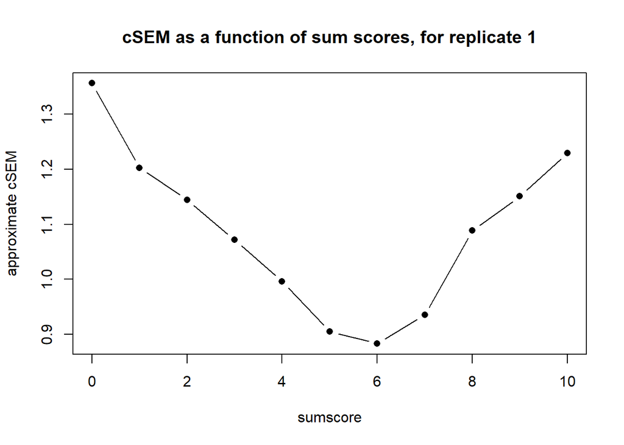

Even with this large sample size there is some variability across replicates. Increasing the sample size does help in reducing this variability, so I am confident that this code is correct.

@Wilco: Wat ik noem: “Approximate population cSEMs” is dat niet. ZOu jij dit willen corrigeren, en aanvullen met de 3 andere opties erbij?

# Sample data, SEMs via alpha, lmer and lme (both with compound symmetry and without)

Now, we generate sample data of size n = 1000. We estimate the SEM via coefficient alpha, and the estimated residuals of a rm-anova, estimated in 3 ways: with 2 types of model specifications (random intercept model without compound symmetry (cs), and with cs), and 2 functions (lmer, lme). We do this for 10 replicates, to assess the stability of estimation.

Estimated SEMs, via alpha, lmer, lme without compound symmetry, and with compound symmetry, for 10 replicates

|  | repl1 | repl2 | repl3 | repl4 | repl5 | repl6 | repl7 | repl8 | repl9 | repl10 |
| --- | --- | --- | --- | --- | --- | --- | --- | --- | --- | --- |
| SEM_alpha | 1.07674 | 1.081028 | 1.075059 | 1.074497 | 1.091523 | 1.099042 | 1.071828 | 1.088461 | 1.07627 | 1.065786 |
| SEM_lmer | 1.07674 | 1.081028 | 1.075059 | 1.074497 | 1.091523 | 1.099042 | 1.071828 | 1.088461 | 1.07627 | 1.065786 |
| SEM_lme_nocs | 1.07674 | 1.081028 | 1.075059 | 1.074497 | 1.091523 | 1.099042 | 1.071828 | 1.088461 | 1.07627 | 1.065786 |
| SEM_lme_cs | 1.07674 | 1.081028 | 1.075059 | 1.074497 | 1.091523 | 1.099042 | 1.071828 | 1.088461 | 1.07627 | 1.065786 |

The estimated SEMs are consistently equal across the four estimates (via alpha, lmer and lme). A NA is due to non-convergence problems.

In general, when trying out different replicates and settings, lmer showed less non-convergence issues than lme. Further, lme_cs (so with compound symmtry imposed) and lme_nocs (without compound symmtry imposed) specify the same models. The model specified with lme_nocs (and lmer) is simply the random intercept model, with level 2 persons, level 1 items, and the items as fixed effects. The model-implied covariance structure is the same as that in a compound symmetry model. Imposing compound symmetry explicitly may steer the algorithm in the correct direction - but in principle it is superfluous.

# Sample data, cSEMs per sumscore, via lmer and lme (with and without compound symmetry)

Now, we generate sample data of size n = 1000. We estimate the cSEMs per sum score, via the estimated residuals of a rm-anova, estimated in 3 ways: with 2 types of model specifications (random intercept model without compound symmetry (cs), and with cs), and 2 functions (lmer, lme).

```
##
##
## Table: Estimated cSEMs per sumscore, via lmer, lme without compound symmetry, and with compound symmetry, for one replicate
##
## |              | sum0|  sum1|  sum2|  sum3|  sum4|  sum5|  sum6|  sum7|  sum8|  sum9| sum10|
## |:-------------|----:|-----:|-----:|-----:|-----:|-----:|-----:|-----:|-----:|-----:|-----:|
## |cSEM_lmer     |    0| 0.858| 1.015| 1.008| 0.952| 0.937| 0.964| 0.865| 0.870| 0.851|     0|
## |cSEM_lme_nocs |   NA| 0.858| 1.015| 1.008| 0.952| 0.937| 0.964| 0.865| 0.870| 0.851|    NA|
## |cSEM_lme_cs   |   NA| 0.814| 0.963| 0.957| 0.903| 0.889| 0.914| 0.821| 0.825| 0.807|    NA|
```

```
##
##
## Table: Estimated cSEMs per sumscore, via lmer, lme without compound symmetry, and with compound symmetry, for one replicate
##
## |              | sum0|  sum1|  sum2| sum3|  sum4|  sum5|  sum6|  sum7|  sum8|  sum9| sum10|
## |:-------------|----:|-----:|-----:|----:|-----:|-----:|-----:|-----:|-----:|-----:|-----:|
## |cSEM_lmer     |    0| 0.880| 0.957| 1.05| 0.945| 0.908| 0.968| 0.852| 0.788| 0.808|     0|
## |cSEM_lme_nocs |   NA| 0.880| 0.957| 1.05| 0.945| 0.908| 0.968| 0.852| 0.788| 0.808|     0|
## |cSEM_lme_cs   |   NA| 0.835| 0.908|   NA| 0.897|    NA| 0.918| 0.809| 0.747| 0.766|    NA|
```

```
##
##
## Table: Estimated cSEMs per sumscore, via lmer, lme without compound symmetry, and with compound symmetry, for one replicate
##
## |              | sum0|  sum1|  sum2|  sum3|  sum4|  sum5|  sum6|  sum7|  sum8|  sum9| sum10|
## |:-------------|----:|-----:|-----:|-----:|-----:|-----:|-----:|-----:|-----:|-----:|-----:|
## |cSEM_lmer     |    0| 0.858| 0.972| 1.047| 0.977| 0.931| 0.923| 0.903| 0.843| 0.742|     0|
## |cSEM_lme_nocs |   NA| 0.858| 0.972| 1.047| 0.977| 0.931| 0.923| 0.903| 0.843| 0.742|    NA|
## |cSEM_lme_cs   |   NA| 0.814|    NA| 0.993| 0.927| 0.883|    NA| 0.856| 0.800| 0.704|    NA|
```

Now, the cSEM_lme_cs estimates are consistently lower than the cSEMs as estimated with lmer and lme, without the cs. Apparently, now requiring the superfluous parameter to estimate makes things differently. I think the cs model is overparametrized, and now results in a non-unique solution. It seems safer to continue with the specification without compound symmetry imposed.

# Sample data, cSEMs per sumscore, via modeling residual variances as a function of the sumscores

Now, we try to model the full sample data (N=1000) with a random effect model, allowing for heteroscedasticity, depending on the sum score (Xplus). We can only do via lme, since lmer does not facilitate heteroscedasticity.  
We do so via an exponential term. We fitted three models: 1. linear effect of Xplus; 2. quadratic effect of Xplus; 3. linear plus quadratic effect of Xplus. For each of the three models, the following is shown: ** The estimates of cSEM per sum score (0 to 10) are printed in a table. ** A residual plot - plotting the fitted values (including the random intercepts) by the normalized residuals.

```
##
##
## Table: Fit
##
## |            |    logLik|      BIC|
## |:-----------|---------:|--------:|
## |lme_lin     | -4205.427| 8530.575|
## |lme_qua     | -4215.788| 8551.297|
## |lme_lin+qua | -4192.861| 8514.652|
##
##
## Table: Estimated cSEMs per sumscore, via model-implied residual variances, for one replicate
##
## |                 |  sum0|  sum1|  sum2|  sum3|  sum4|  sum5|  sum6|  sum7|  sum8|  sum9| sum10|
## |:----------------|-----:|-----:|-----:|-----:|-----:|-----:|-----:|-----:|-----:|-----:|-----:|
## |cSEM_lme_lin     | 1.230| 1.203| 1.176| 1.149| 1.123| 1.098| 1.073| 1.049| 1.025| 1.002| 0.980|
## |cSEM_lme_qua     | 1.238| 1.171| 1.122| 1.089| 1.069| 1.062| 1.069| 1.089| 1.122| 1.171| 1.238|
## |cSEM_lme_lin+qua | 1.493| 1.351| 1.242| 1.160| 1.102| 1.063| 1.043| 1.039| 1.052| 1.083| 1.133|
```

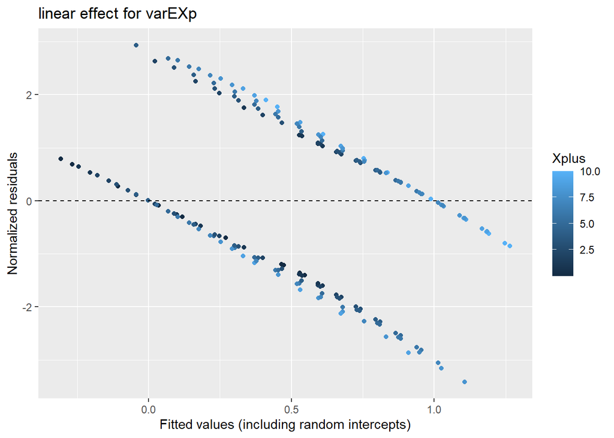

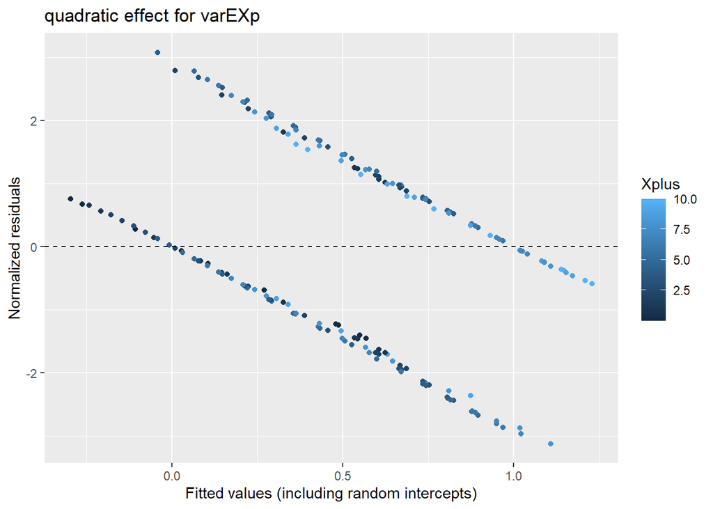

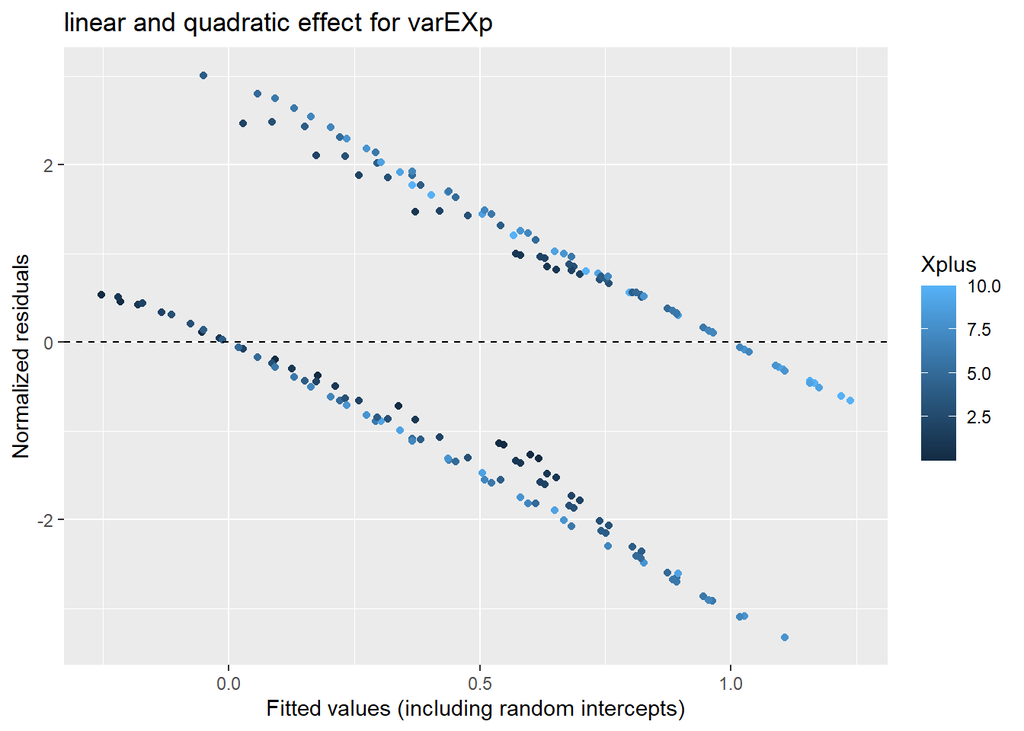

The model with the lowest BIC is **lme_lin+qua**.

# Future work

** Willen we nog flexibelere variantiefuncties (splines, smooths), dan lijkt het erop dat we Bayesiaans moeten gaan, via brms, of Stan. Daarover gaat de volgende Note.